# Sentiment Analysis using Twitter Data - georgefloyd

Yashvi Malviya

```r
packages <- c("readxl","tidytext","plyr","dplyr","tidyr","ggplot2","scales",
              "purrr","textdata","wordcloud","reshape2","stringr","igraph",
              "ggraph","widyr","grid","arules","tm","topicmodels")
for(i in packages){
  if(!require(i,character.only = T, quietly = T)){
    install.packages(i)
  }
  library(i, character.only = T, quietly = T)
}

rm(list=ls())

set.seed(2020)
```

# Loading Data

```r
library(readr)
tweets1 <- read.csv("week2.csv", header = TRUE)
tweets2 <- read.csv("week3.csv", header = TRUE)
tweets3 <- read.csv("week5.csv", header = TRUE)
tweets4 <- read.csv("week6.csv", header = TRUE)
tweets5 <- read.csv("week11.csv", header = TRUE)
tweets6 <- read.csv("week12.csv", header = TRUE)
```

# Data Wrangling

## Data Clean Using Customized Functions

```r
dfList<-list(tweets1,tweets2,tweets3,tweets4,tweets5,tweets6)
result_list <- lapply(dfList, function(x) {
  cat("Original column names:\n")
  print(colnames(x))
  english_tweets <- subset(x, x$`19: Language` == "English")

  cat("\nColumn names after subset:\n")
  print(colnames(english_tweets))
  if (nrow(english_tweets) > 0) {
    english_tweets$tweet <- english_tweets$`X2..Tweet`
    english_tweets <- english_tweets[, c("tweet")]
    cat("\nColumn names after adding 'tweet':\n")
    print(colnames(english_tweets))
    english_tweets$tweetnumber <- 1:nrow(english_tweets)

    cat("\nStructure of the cleaned dataframe:\n")
    print(str(english_tweets))

    return(english_tweets)
  } else {
    cat("\nNo English tweets remaining.\n")
    return(data.frame())
  }
})
```

```
## Original column names:
##  [1] "X1..Date.Time"             "X2..Tweet"
##  [3] "X3..Hashtags"              "X4..Type"
##  [5] "X5..Reply.to"              "X6..Author"
##  [7] "X7..Author.s.real.name"    "X8..Author.s.location"
##  [9] "X9..Author.s.timezone"     "X10..Author.s.URL"
## [11] "X11..Author.s.description" "X12..Followers"
## [13] "X13..Follows"              "X14..Tweets"
## [15] "X15..Profile.verified"     "X16..Profile.created"
## [17] "X17..Retweets"             "X18..Likes"
## [19] "X19..Language"             "X20..Source"
## [21] "X21..Tweet.coordinates"
##
## Column names after subset:
##  [1] "X1..Date.Time"             "X2..Tweet"
```

[output cut: 147 more lines]

The function gives us 6 data sets with only 2 variables: tweet and tweetnumber and we want to keep tweetnumber to track down every word from the tweet text later.

## Stop Words

```r
data(stop_words)
custom_stop_words <- bind_rows(
  tibble(word = c("t.co","csun","blm","rt","https",
                  "BLM","blacklivesmatter","black",
                  "georgefloyd","2",'#blm','#blacklivesmatter',
                  '#georgefloyd','august'),
         lexicon = c("custom")), stop_words)
```

We want to have some stop words for our analysis so that those wouldn’t appear in our frequency table and interfere our judgment.

## Extract Tokens

```r
remove_reg <- "&amp;|&lt;|&gt;"
dfList2 <- list(tweets1, tweets2, tweets3, tweets4, tweets5, tweets6)
result_list2 <- lapply(dfList2, function(x) {
  print(colnames(x))

  x %>%
    mutate(tweet = str_remove_all(`X2..Tweet`, remove_reg)) %>%
    unnest_tokens(output = "word", input = "tweet") %>%
    filter(!word %in% custom_stop_words$word,
           !word %in% str_remove_all(custom_stop_words$word, "'"),
           str_detect(word, "[a-z]"))
})
```

```
##  [1] "X1..Date.Time"             "X2..Tweet"
##  [3] "X3..Hashtags"              "X4..Type"
##  [5] "X5..Reply.to"              "X6..Author"
##  [7] "X7..Author.s.real.name"    "X8..Author.s.location"
##  [9] "X9..Author.s.timezone"     "X10..Author.s.URL"
## [11] "X11..Author.s.description" "X12..Followers"
## [13] "X13..Follows"              "X14..Tweets"
## [15] "X15..Profile.verified"     "X16..Profile.created"
## [17] "X17..Retweets"             "X18..Likes"
## [19] "X19..Language"             "X20..Source"
## [21] "X21..Tweet.coordinates"
##  [1] "X1..Date.Time"             "X2..Tweet"
##  [3] "X3..Hashtags"              "X4..Type"
##  [5] "X5..Reply.to"              "X6..Author"
##  [7] "X7..Author.s.real.name"    "X8..Author.s.location"
```

[output cut: 51 more lines]

```r
tidy1 <- as.data.frame(result_list2[[1]])
tidy2 <- as.data.frame(result_list2[[2]])
tidy3 <- as.data.frame(result_list2[[3]])
tidy4 <- as.data.frame(result_list2[[4]])
tidy5 <- as.data.frame(result_list2[[5]])
tidy6 <- as.data.frame(result_list2[[6]])
```

Each single word in each tweet is considered as a token. By doing so, we can start to count frequency of each word or even each pair of words.

# Data Analysis and Visualization

## Visualize the Most Common Words

```r
# Count the Frequency for Each Word
tidy_week11 <- tidy1 %>% dplyr::count(word, sort = TRUE)
tidy_week12 <- tidy2 %>% dplyr::count(word, sort = TRUE)
tidy_week21 <- tidy3 %>% dplyr::count(word, sort = TRUE)
tidy_week22 <- tidy4 %>% dplyr::count(word, sort = TRUE)
tidy_week31 <- tidy5 %>% dplyr::count(word, sort = TRUE)
tidy_week32 <- tidy6 %>% dplyr::count(word, sort = TRUE)

# Remove all non-english tokens
tidy1_english <- tidy_week11[which(!grepl("[^\x01-\x7F]+", tidy_week11$word)),]
tidy2_english <- tidy_week12[which(!grepl("[^\x01-\x7F]+", tidy_week12$word)),]
tidy3_english <- tidy_week21[which(!grepl("[^\x01-\x7F]+", tidy_week21$word)),]
tidy4_english <- tidy_week22[which(!grepl("[^\x01-\x7F]+", tidy_week22$word)),]
tidy5_english <- tidy_week31[which(!grepl("[^\x01-\x7F]+", tidy_week31$word)),]
tidy6_english <- tidy_week32[which(!grepl("[^\x01-\x7F]+", tidy_week32$word)),]
```

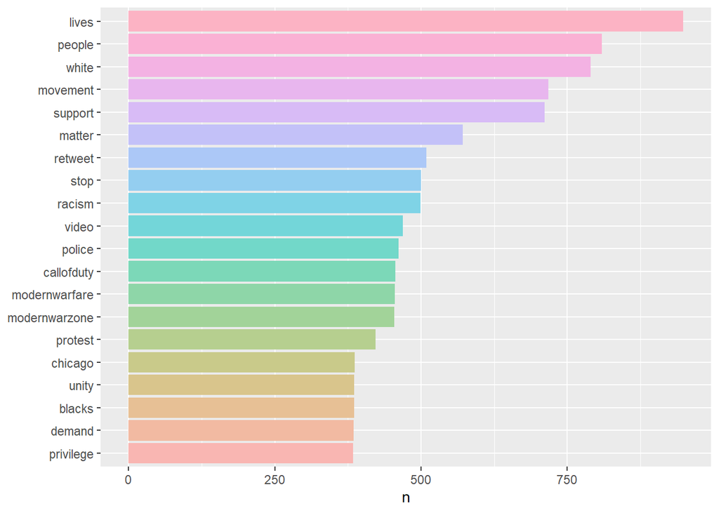

```r
dfList3<-list(tidy1_english,tidy2_english,tidy3_english,tidy4_english,tidy5_english,tidy6_english)


result_list3 <-
  llply(dfList3, function(x) {
    plot <- x %>%
    dplyr::top_n(20) %>%
    dplyr::mutate(word = reorder(word, n)) %>%
    ggplot(aes(word, n, fill=word)) +
    geom_bar(stat="identity")+
    scale_fill_hue(c=45, l=80)+
    xlab(NULL) +
    coord_flip()+
    theme(legend.position="none")
    return(plot)})

result_list3[[1]]
```

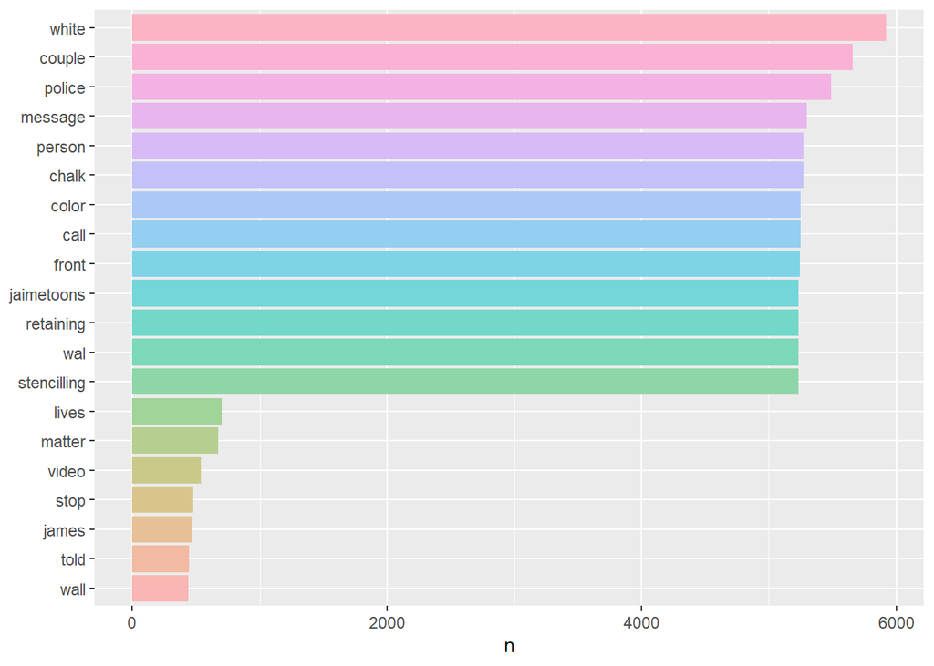

```r
result_list3[[2]]
```

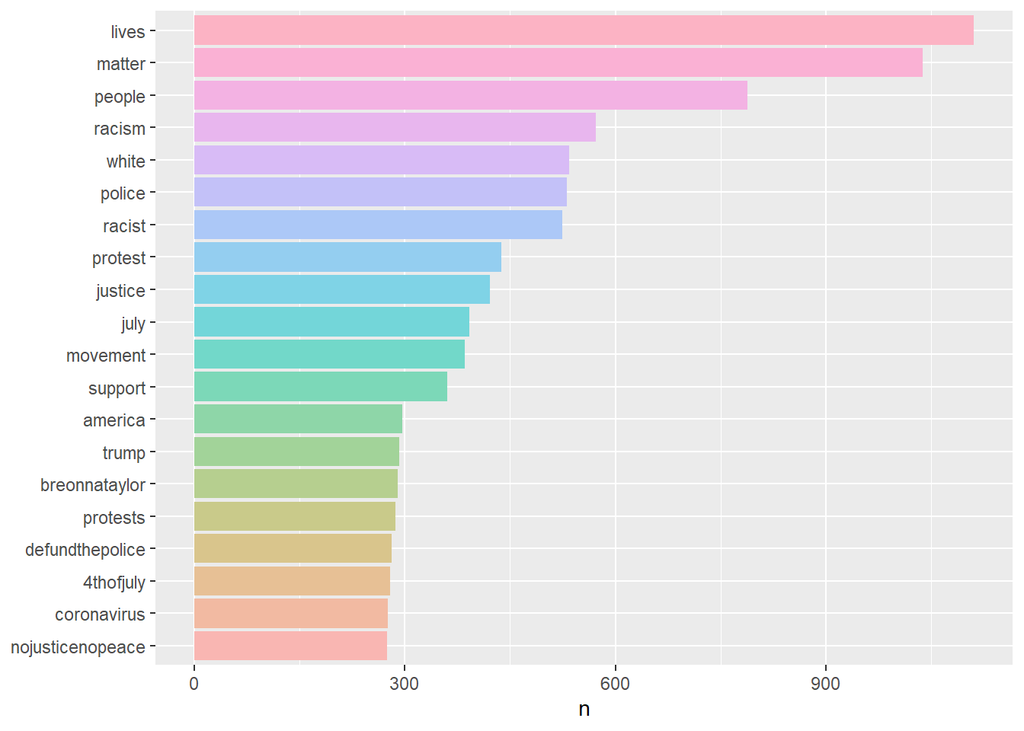

```r
result_list3[[3]]
```

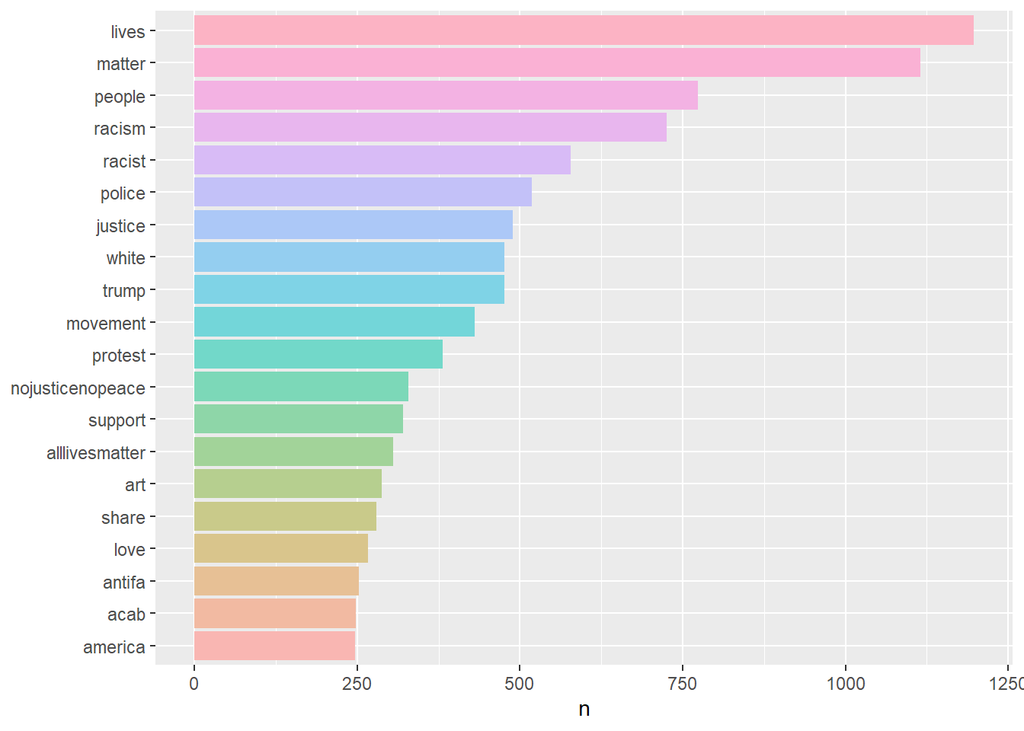

```r
result_list3[[4]]
```

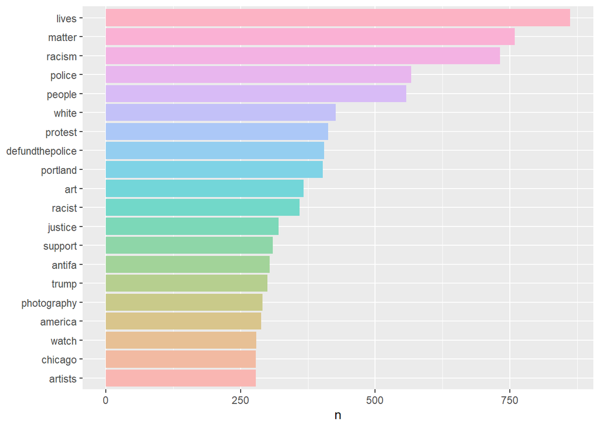

```r
result_list3[[5]]
```

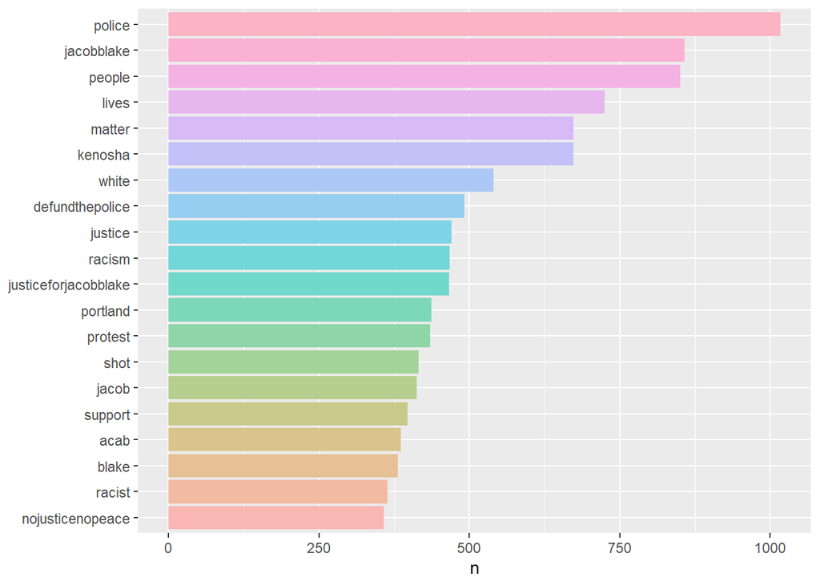

```r
result_list3[[6]]
```

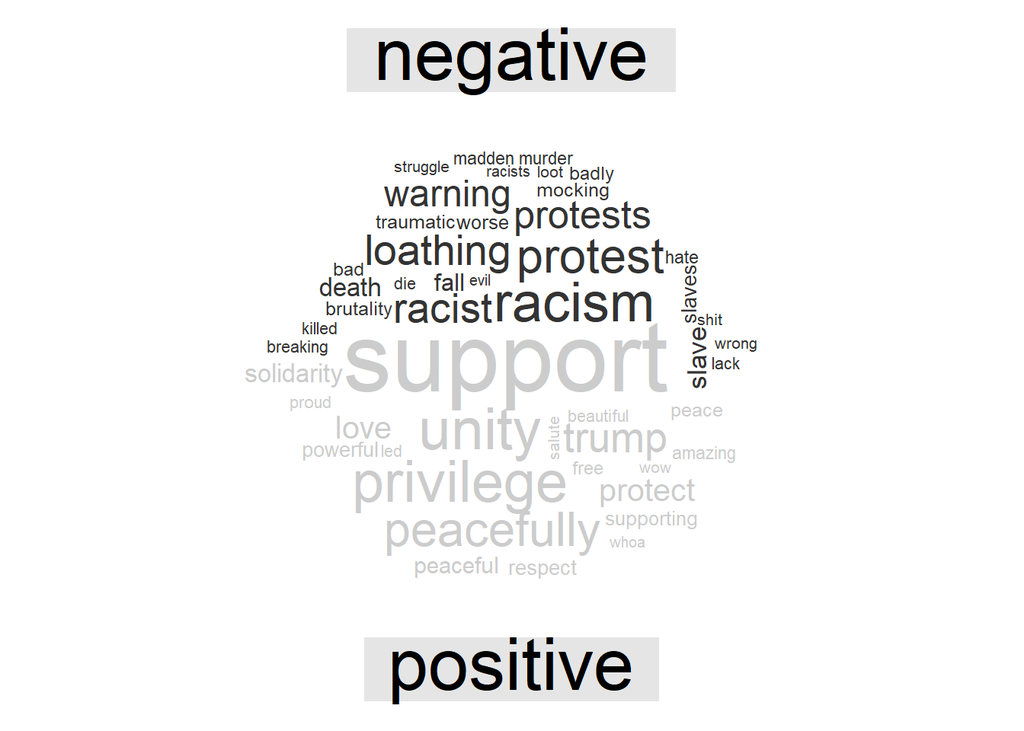

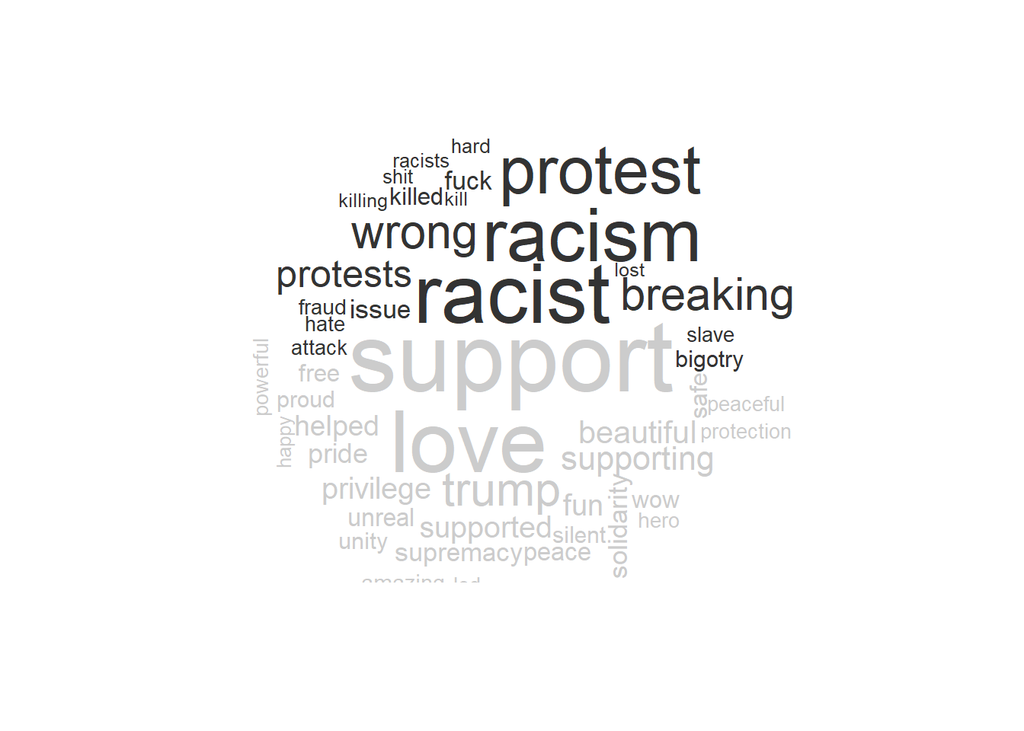

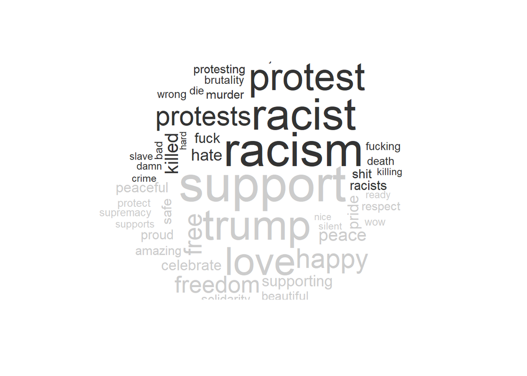

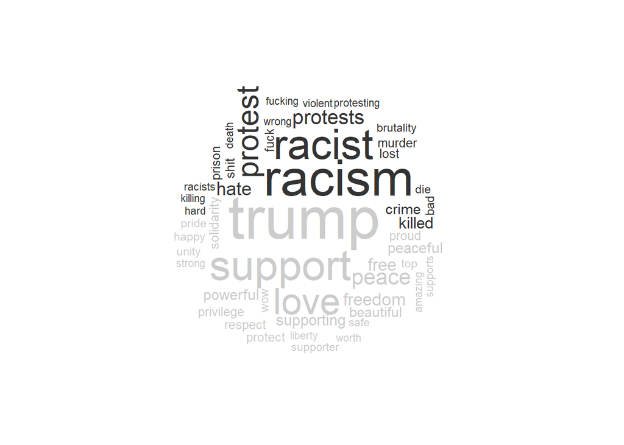

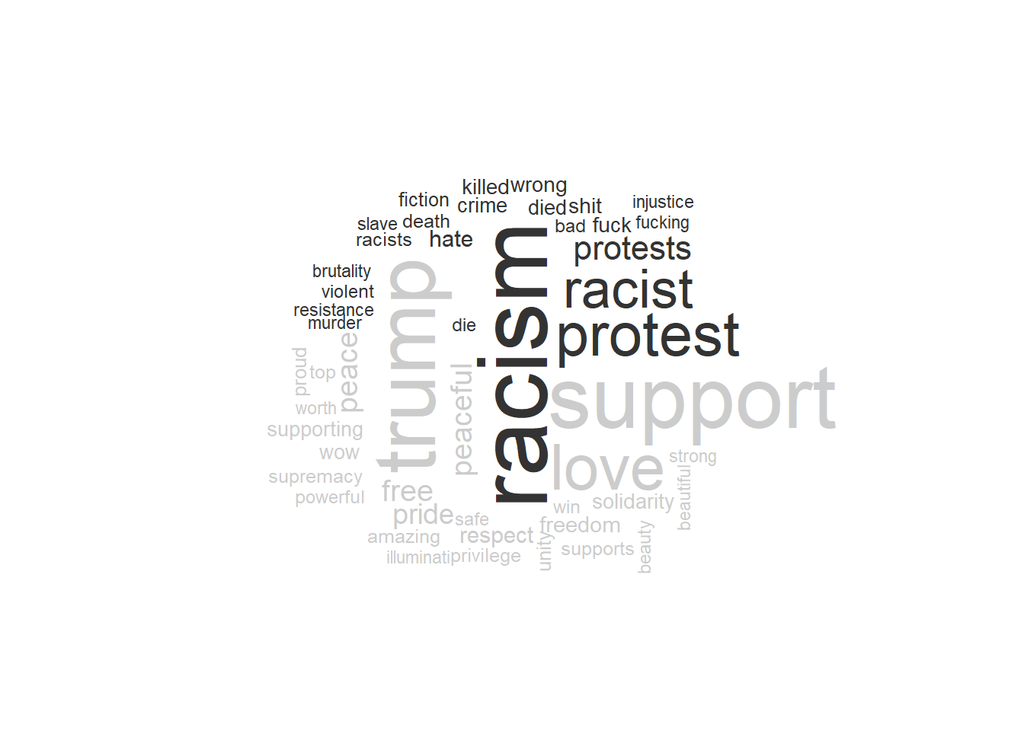

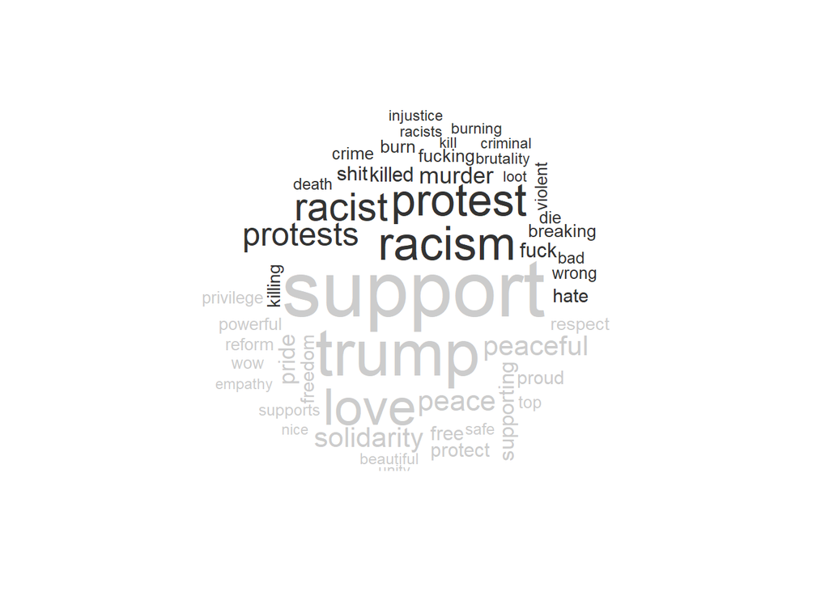

```r
dfList4<-list(tidy1,tidy2,tidy3,tidy4,tidy5,tidy6)
#visualize using Word clouds
result_list_wordclouds <-
  llply(dfList4, function(x) {
    plot <- x %>%
    inner_join(get_sentiments("bing")) %>%
    count(word, sentiment, sort = TRUE) %>%
    acast(word ~ sentiment, value.var = "n", fill = 0) %>%
    comparison.cloud(colors = c("gray20", "gray80"),max.words = 50)
    return(plot)})
```

Word clouds can show both of the most common negative words and the most common positive words.

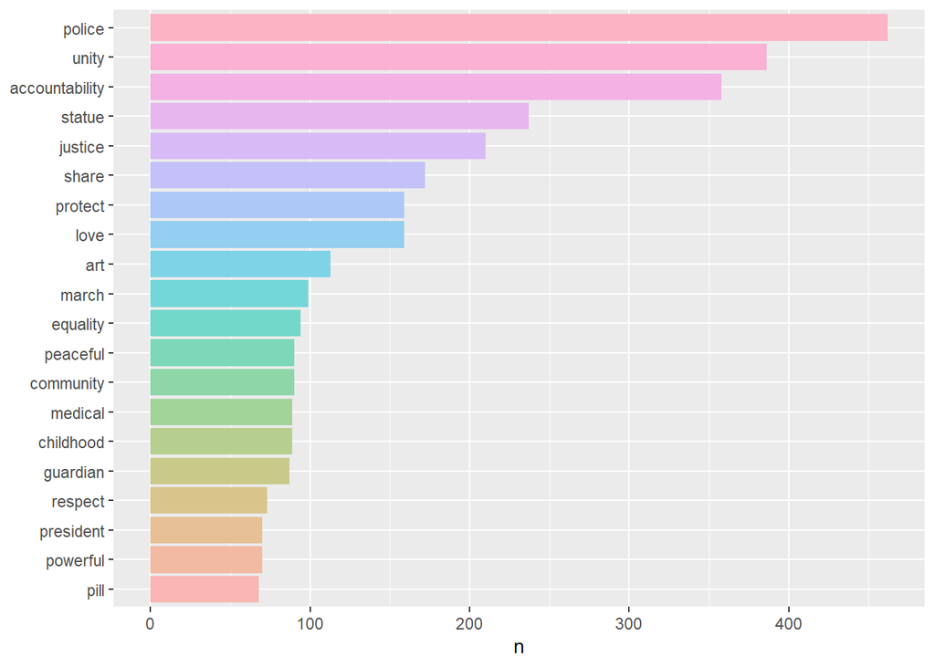

```r
#Finding the most common positive words
nrc_positive <- get_sentiments("nrc") %>%
  filter(sentiment == "positive")

result_list4 <-
  llply(dfList4, function(x) {
    plot <- x %>%
    inner_join(nrc_positive) %>%
    dplyr::count(word, sort = TRUE) %>%
    dplyr::top_n(20) %>%
    dplyr::mutate(word = reorder(word, n)) %>%
    ggplot(aes(word, n, fill=word)) +
    geom_bar(stat="identity")+
    scale_fill_hue(c=45, l=80)+
    xlab(NULL) +
    coord_flip()+
    theme(legend.position="none")
    return(plot)})

result_list4[[1]]
```

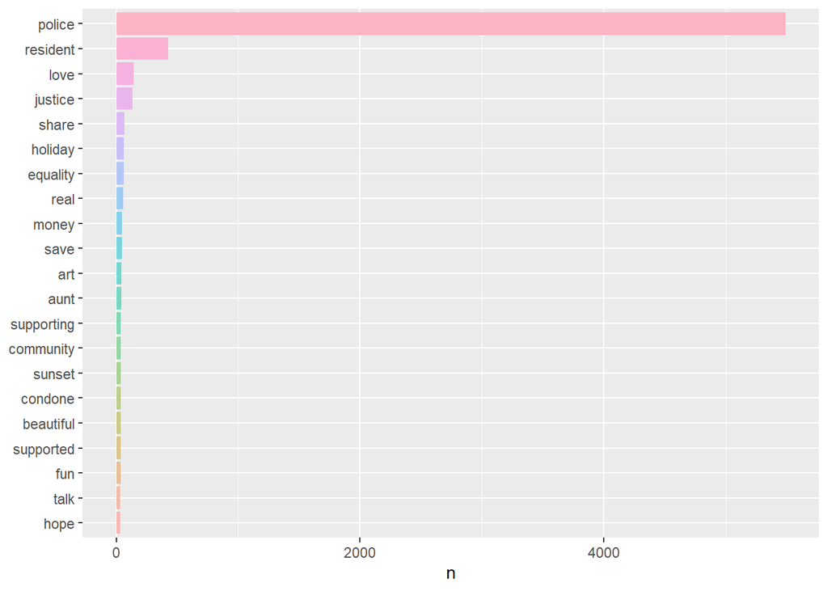

```r
result_list4[[2]]
```

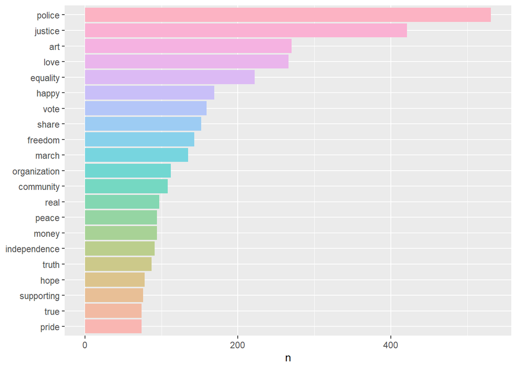

```r
result_list4[[3]]
```

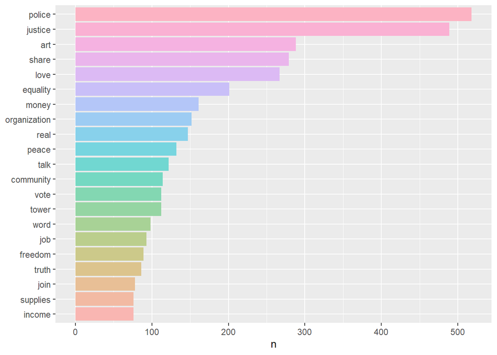

```r
result_list4[[4]]
```

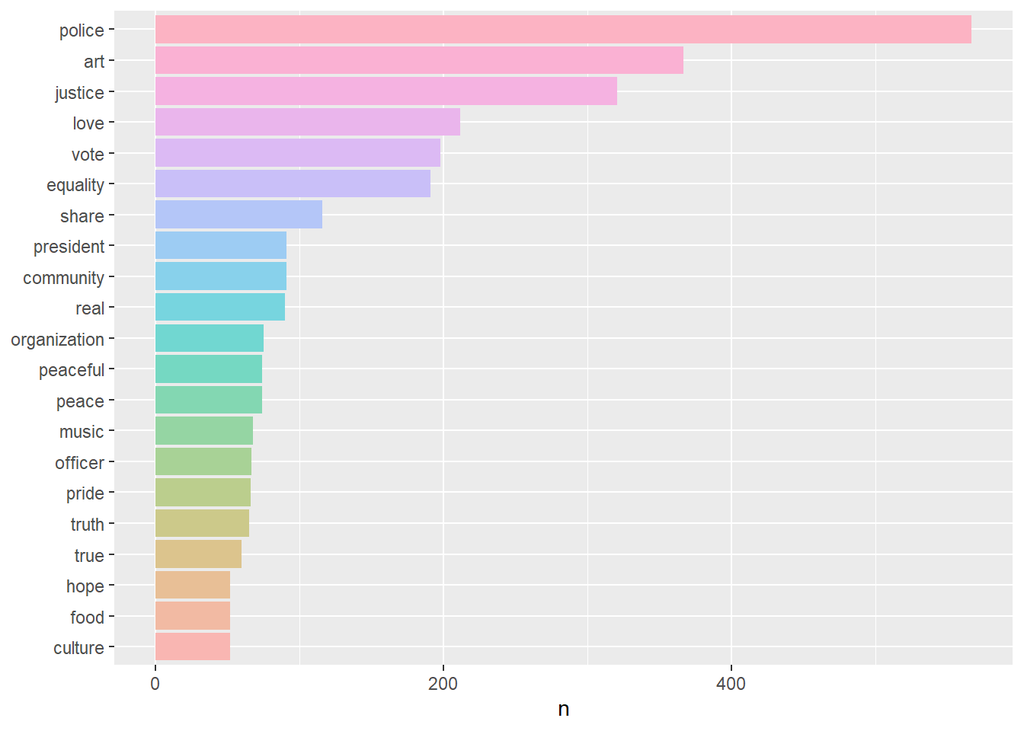

```r
result_list4[[5]]
```

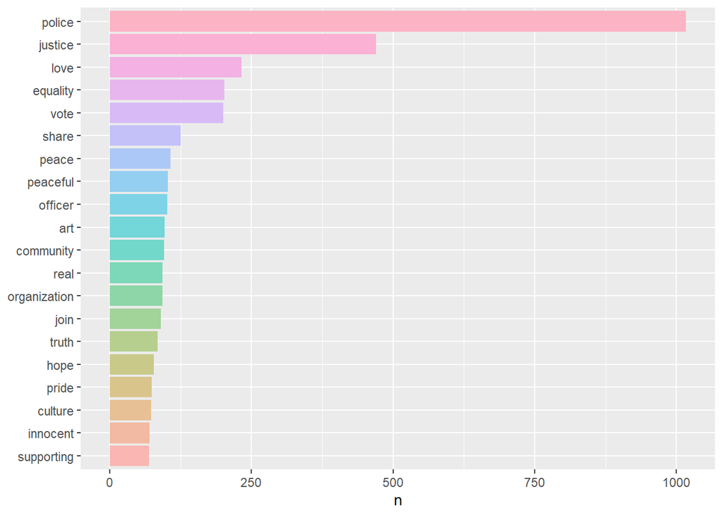

```r
result_list4[[6]]
```

Overall trend: At first, people called on love, unity, and justice. Then they began to call on donations. Later, they tried to appeal on voting to pursue justice again. They wanted the government/legal authority to act upon this.

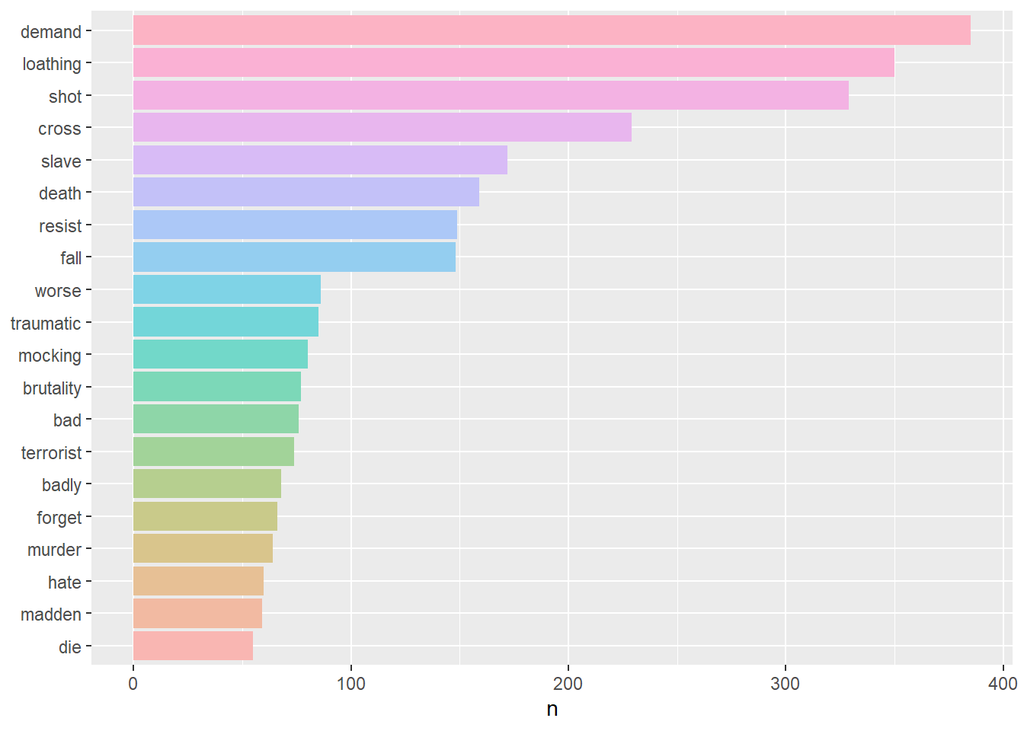

```r
#Find the most common negative words using lexicon
nrc_negative <- get_sentiments("nrc") %>%
  filter(sentiment == "negative")

result_list5 <-
  llply(dfList4, function(x) {
    plot <- x %>%
    inner_join(nrc_negative) %>%
    dplyr::count(word, sort = TRUE) %>%
    dplyr::top_n(20) %>%
    dplyr::mutate(word = reorder(word, n)) %>%
    ggplot(aes(word, n, fill=word)) +
    geom_bar(stat="identity")+
    scale_fill_hue(c=45, l=80)+
    xlab(NULL) +
    coord_flip()+
    theme(legend.position="none")
    return(plot)})

result_list5[[1]]
```

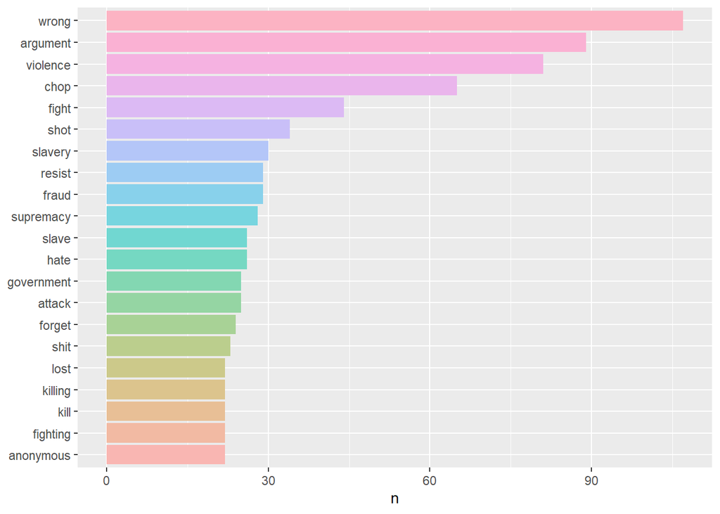

```r
result_list5[[2]]
```

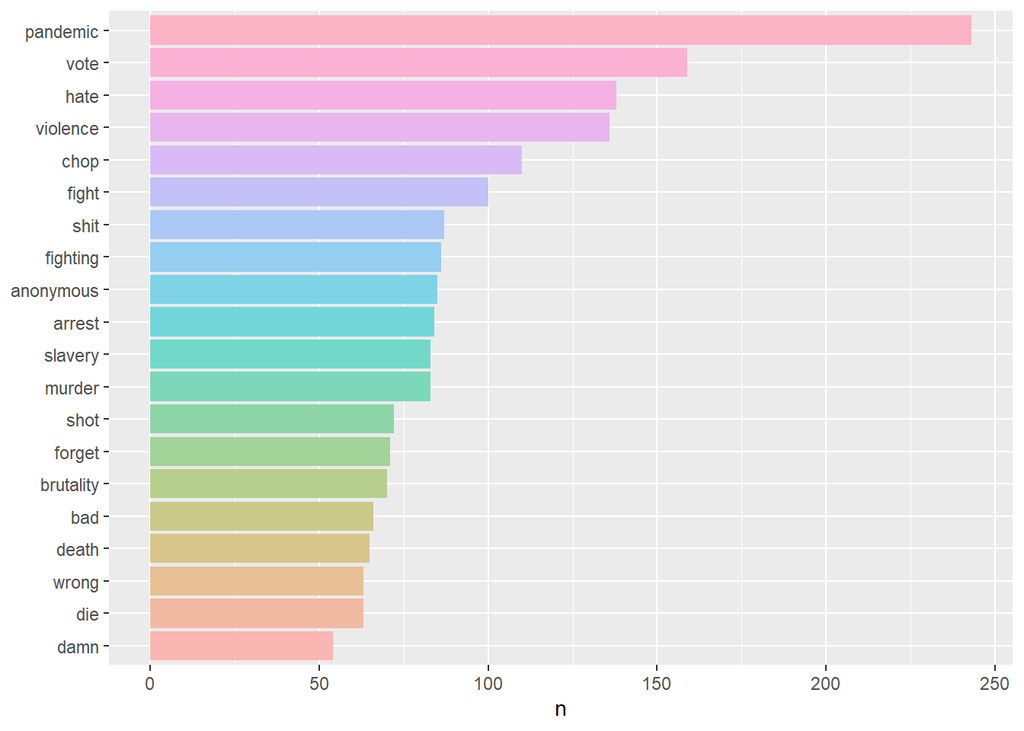

```r
result_list5[[3]]
```

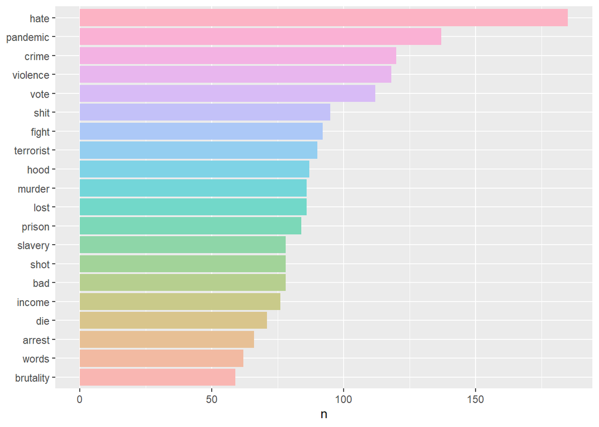

```r
result_list5[[4]]
```

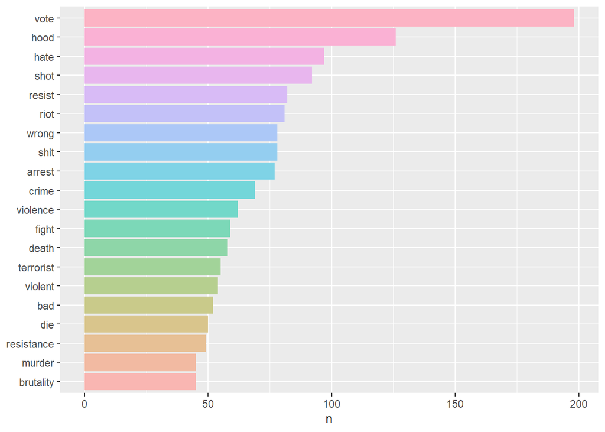

```r
result_list5[[5]]
```

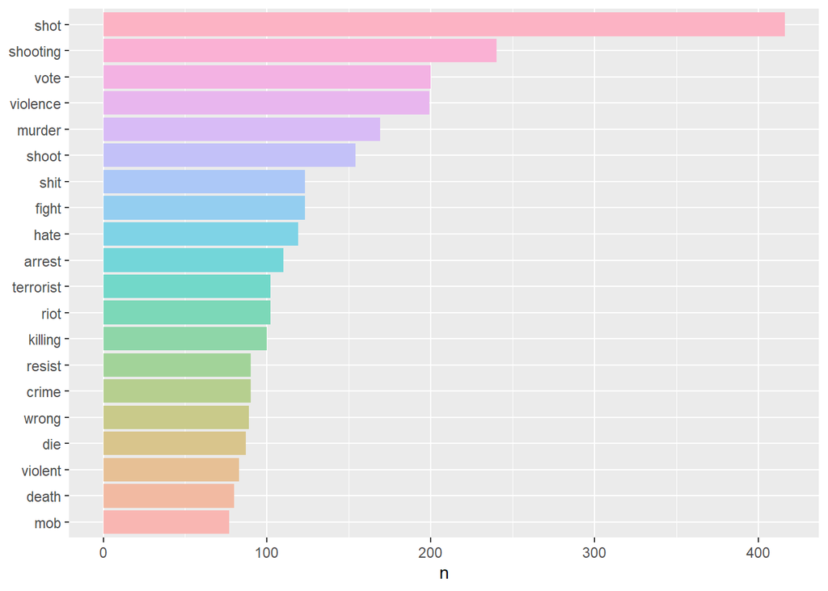

```r
result_list5[[6]]
```

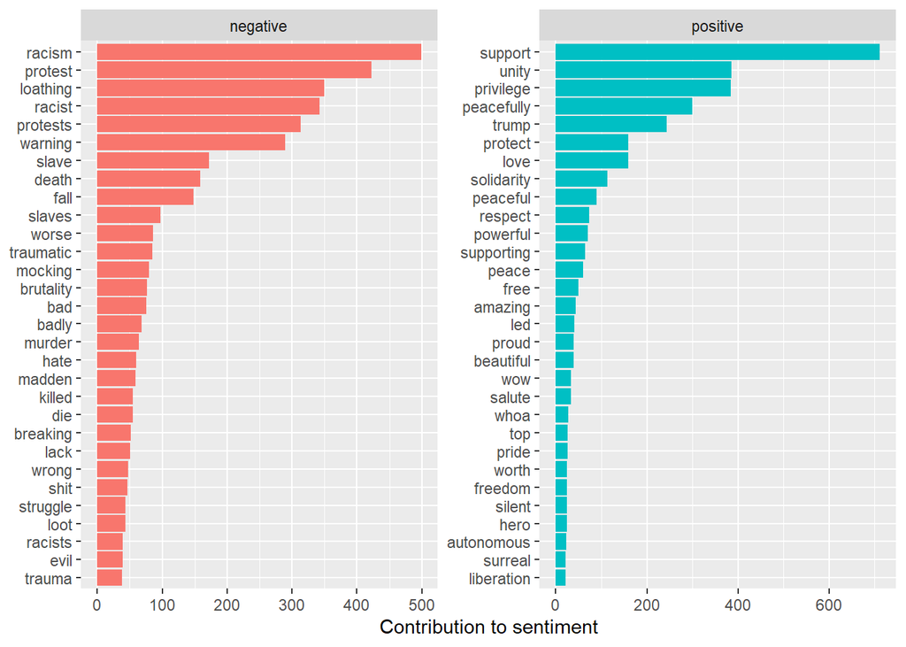

```r
#how much each word contributed to each sentiment.
result_list_contribute <-
  llply(dfList4, function(x) {
    plot <- x %>%
    inner_join(get_sentiments("bing")) %>%
    dplyr::count(word, sentiment, sort = TRUE)  %>%
    group_by(sentiment) %>%
    top_n(30) %>%
    mutate(word = reorder(word, n)) %>%
    ggplot(aes(word, n, fill = sentiment)) +
    geom_col(show.legend = FALSE) +
    facet_wrap(~sentiment, scales = "free") +
    labs(y = "Contribution to sentiment",
         x = NULL) +
    coord_flip()
    return(plot)})

result_list_contribute[[1]]
```

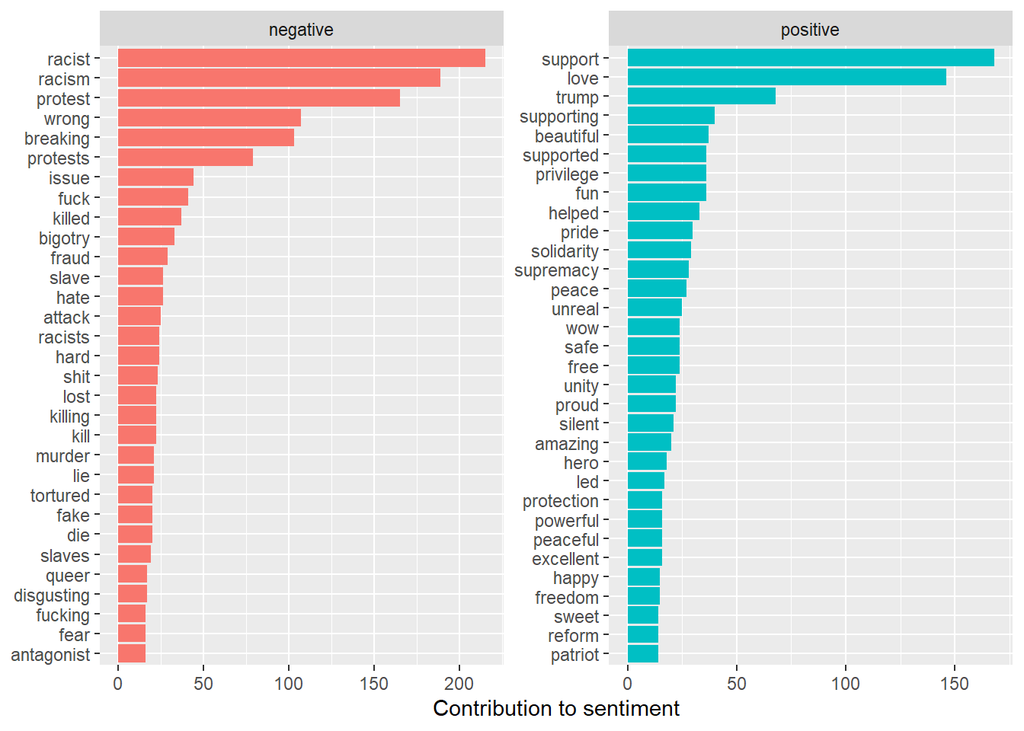

```r
result_list_contribute[[2]]
```

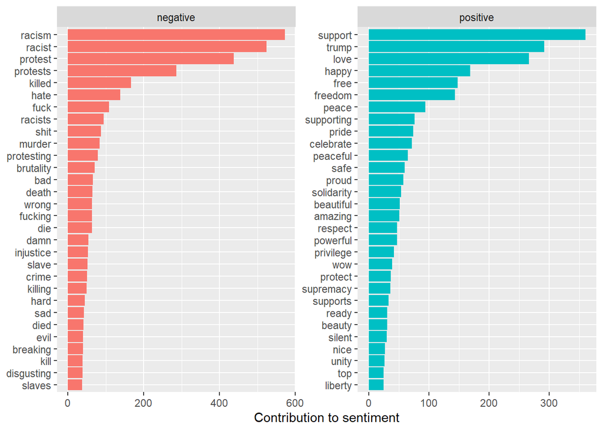

```r
result_list_contribute[[3]]
```

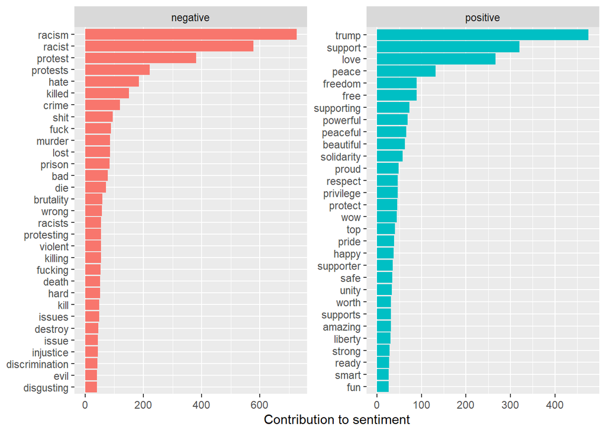

```r
result_list_contribute[[4]]
```

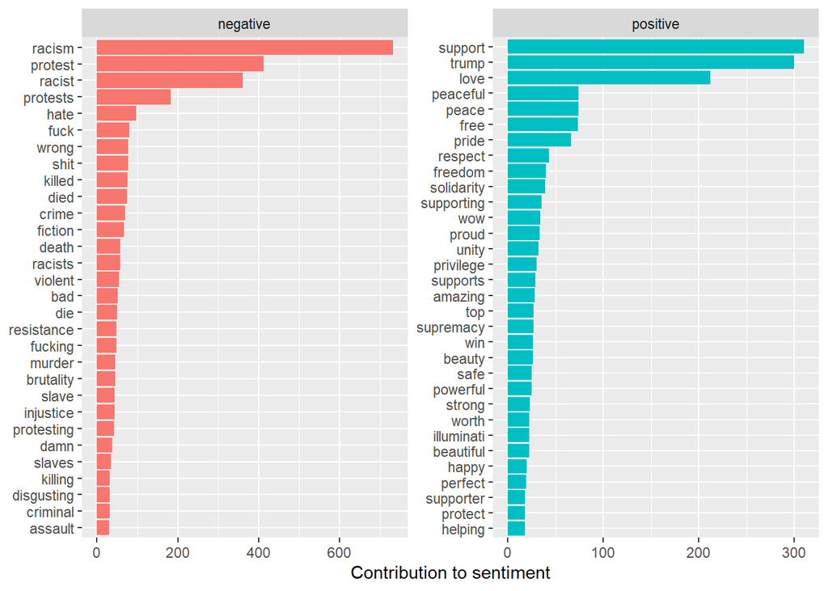

```r
result_list_contribute[[5]]
```

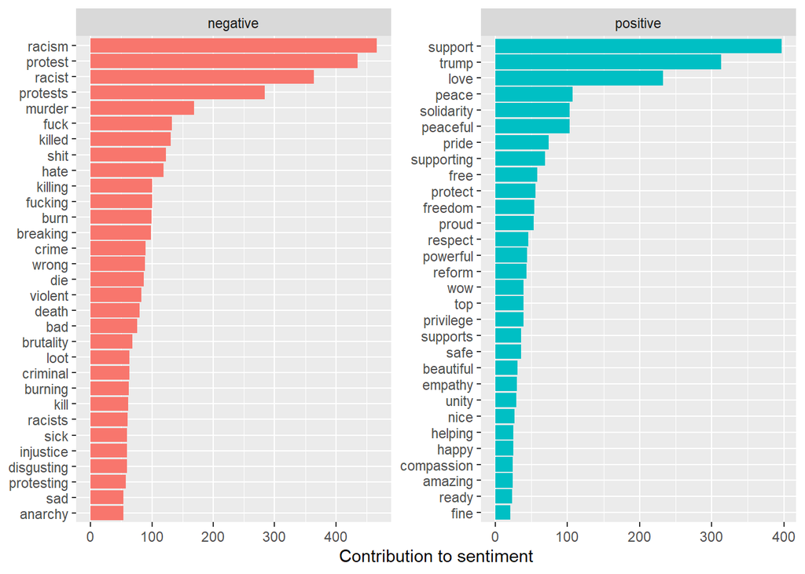

```r
result_list_contribute[[6]]
```